# R Notebook

Mohsen Sadatsafavi

February 11, 2026

```r
library(dplyr)
library(cumulcalib)
library(predtools)

source("core.r")

res_path <- "M:/Projects/2025/Project.cumulcalibBenefit/results/wip/"  #Trailing / is required!


collector <- list()

my_format <- function(val, n_digits=4)
{
  format(round(val,n_digits),nsmall=n_digits, big.mark=",")
}
```

### GUSTO

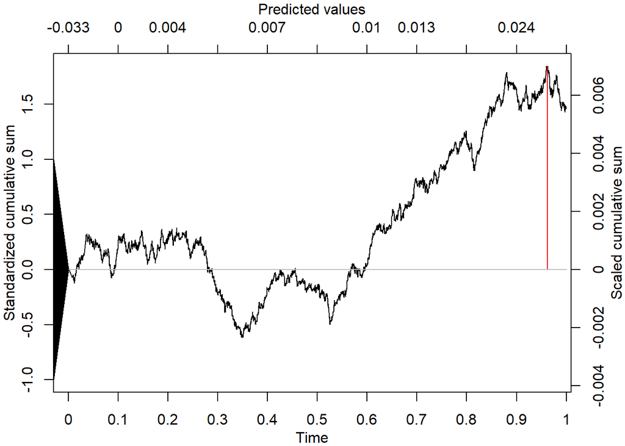

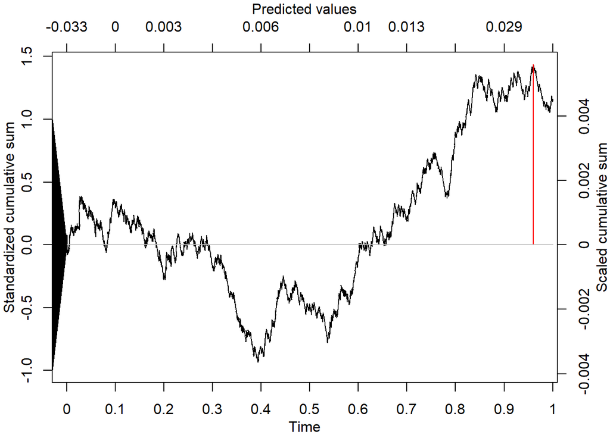

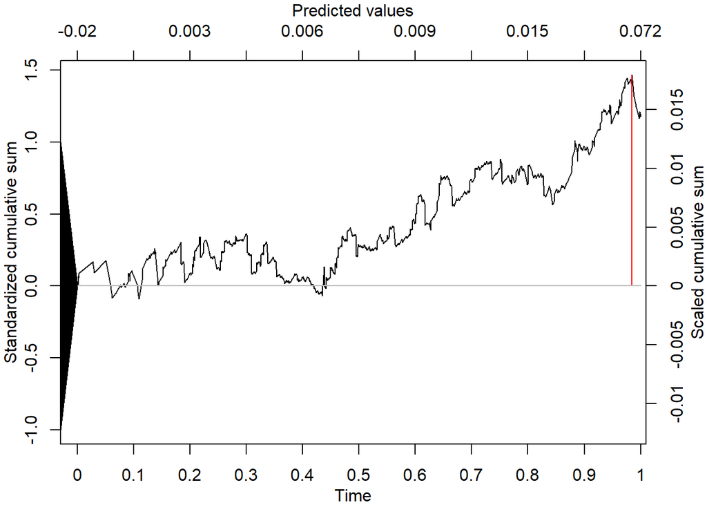

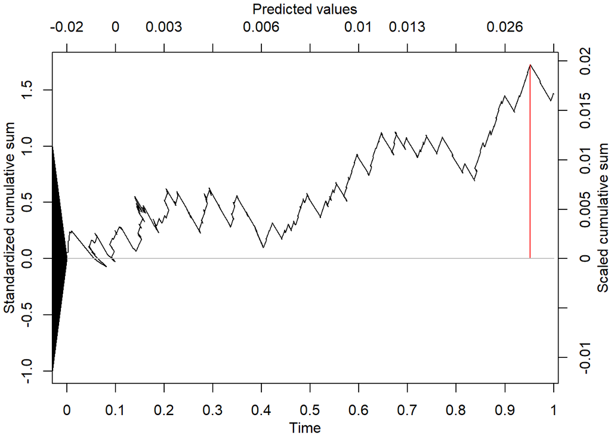

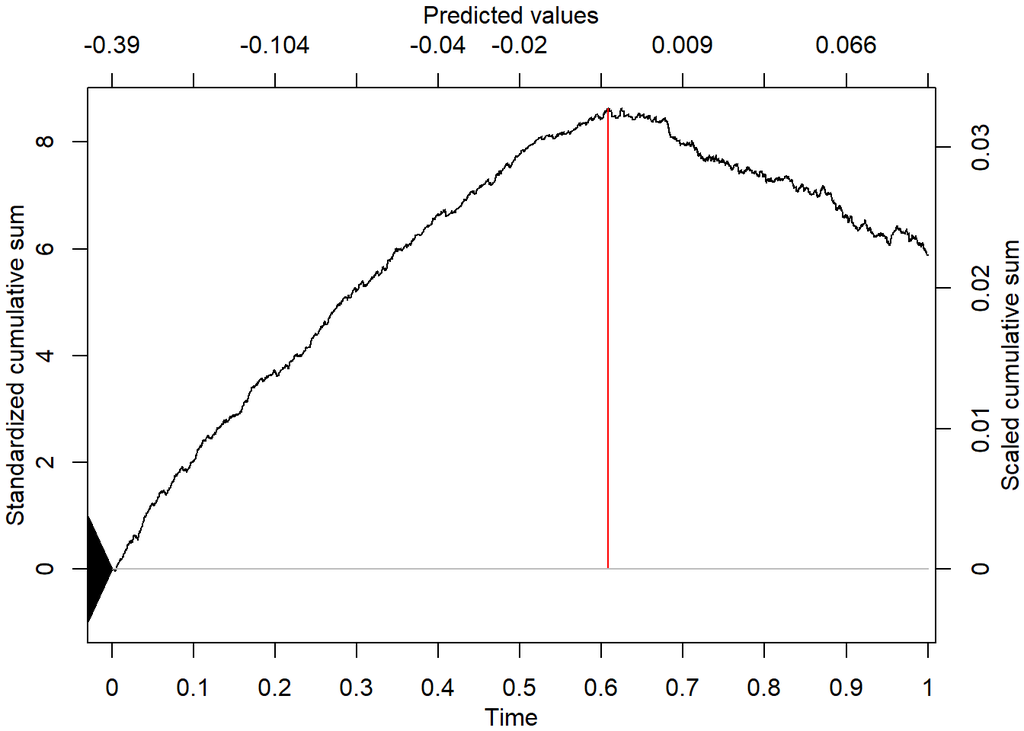

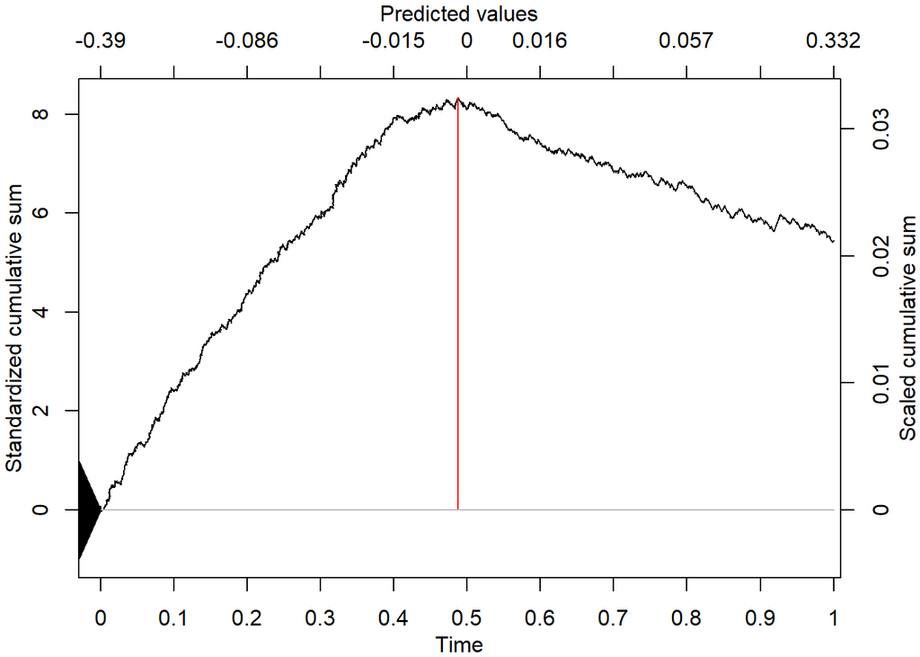

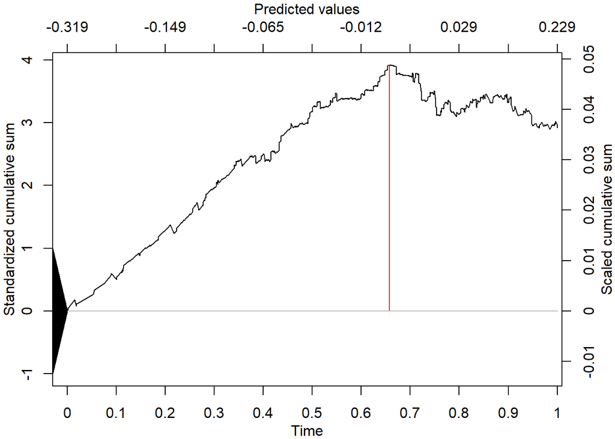

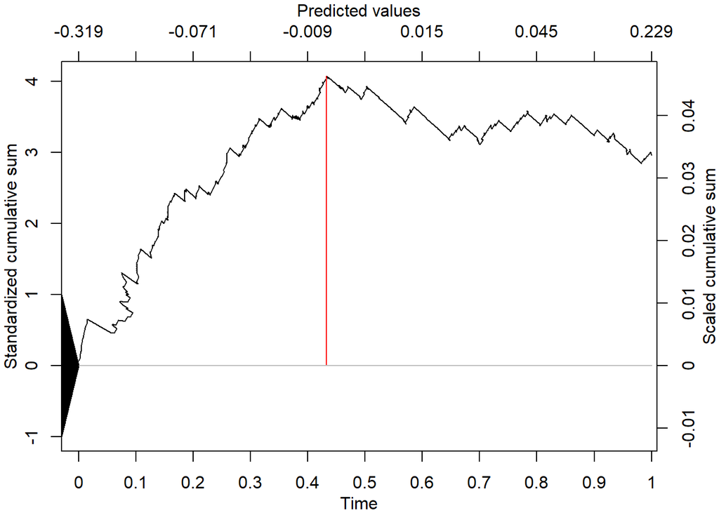

```r
set.seed(122)

data(gusto)

## Coding the treatment groups ##
df <- gusto %>% filter(tx!="SK+tPA")
df$a <- ifelse(df$tx=="tPA", 1, 0)*1 ## 1 for TPA 0 for other (SKA or SKA combo)
df$Y <- df$day30
df$kill <- (as.numeric(df$Killip)>1)*1 ## Killip Class Binary (0 = KC 1)

data_us <- df[df$regl %in% c(1, 7, 9, 10, 11, 12, 14, 15),]
data_other <- df[!df$regl %in% c(1, 7, 9, 10, 11, 12, 14, 15),]

dev_dataL <- data_other ## training data
dev_dataS <- data_other[sample(nrow(data_other), round(nrow(data_other)/10)),]

val_dataL <- data_us ## validation data
val_dataS <- data_us[sample(nrow(data_us), round(nrow(data_us)/10)),]


collector$gusto$sample_sizes <- c(devS=nrow(dev_dataS), devL=nrow(dev_dataL), valS=nrow(val_dataS), valL=nrow(val_dataL))

collector$gusto$prevs <- c(devS=mean(dev_dataS$Y), devL=mean(dev_dataL$Y), valS=mean(val_dataS$Y), valL=mean(val_dataL$Y))
tmp <- cbind(devS=ate(dev_dataS$Y, dev_dataS$a), devL=ate(dev_dataL$Y,dev_dataL$a), valS=ate(val_dataS$Y,val_dataS$a), valL=ate(val_dataL$Y,val_dataL$a))
collector$gusto$ATEs <- tmp[1,]
collector$gusto$ATE_SEs <- sqrt(tmp[2,])


ite_modelL <- glm(Y ~ sex + age + miloc + pmi + kill + pmin(sysbp,100) + pulse +
                   a + a:sex + a:age, data = dev_dataL,
                  family=binomial(link="logit"))


ite_modelS <- glm(Y ~ sex + age + miloc + pmi + kill + pmin(sysbp,100) + pulse +
                   a + a:sex + a:age, data = dev_dataS,
                  family=binomial(link="logit"))

collector$gusto$modelS$model <- summary(ite_modelS)
collector$gusto$modelL$model <- summary(ite_modelL)



for(src in c("L","S"))
  for(dest in c("L","S")){
    ite_model <- get(paste0("ite_model",src))
    dt <- get(paste0("val_data",dest))
    tmp <- dt
    tmp$a<-0
    p0 <- predict(ite_model, newdata=tmp, type="response")
    tmp$a<-1
    p1 <- predict(ite_model, newdata=tmp, type="response")
    df <- data.frame(Y=dt$Y, p0=p0, h=p0-p1, t=dt$a)
    df <- df[order(df$h),]

    res <- cumulcalibITE(df$Y, df$h, df$t, df$p0, method = c("BM","BB"))
    png(paste0(res_path,"gusto_rw_",src,dest,"1.png"), width = 2000, height = 1500, res = 300)
    # De-emphasize inference: mark the maximum cumulative error C* (method BM),
    # drop significance thresholds. This keeps the figure marker aligned with the
    # C* direction reported in the tables.
    plot(res, method = "BM", stats_config = list(lines = "v"))
    dev.off()
    plot(res, method = "BM", stats_config = list(lines = "v"))
    collector$gusto[[paste0("res",src,dest,"1")]] <- res

    res <- cumulcalibITE(df$Y, df$h, df$t, method = c("BM","BB"))
    png(paste0(res_path,"gusto_rw_",src,dest,"2.png"), width = 2000, height = 1500, res = 300)
    plot(res, method = "BM", stats_config = list(lines = "v"))
    dev.off()
    plot(res, method = "BM", stats_config = list(lines = "v"))
    collector$gusto[[paste0("res",src,dest,"2")]] <- res
  }
```

```r
saveRDS(collector, paste0(res_path,"collector.RDS"))
```

### Flexible (LOESS-based) calibration plots (experimental)

Conventional counterpart to the cumulative calibration plots. Because the true ITE is not observed at the individual level, we estimate it by smoothing the outcome against the predicted ITE separately within each treatment arm and taking the difference: for a predicted ITE $\delta$, the estimated true ITE is $\widehat{E}(Y\mid a=0,\delta) - \widehat{E}(Y\mid a=1,\delta)$ (control risk minus treated risk). The dashed line is the identity (perfect moderate calibration). Each panel overlays two LOESS bandwidths (span) on the same data to show how the analyst’s smoothing choice shifts the qualitative read; uncertainty bands are omitted for legibility. Uses the models and validation samples created in the GUSTO chunk above.

```r
flex_calib <- function(ite_model, val, span = 0.75, trim = 0.02) {
  tmp <- val; tmp$a <- 0; p0 <- predict(ite_model, newdata = tmp, type = "response")
  tmp$a <- 1;            p1 <- predict(ite_model, newdata = tmp, type = "response")
  d <- data.frame(Y = val$Y, h = p0 - p1, a = val$a)
  lo0 <- loess(Y ~ h, data = d[d$a == 0, ], span = span)   # control arm
  lo1 <- loess(Y ~ h, data = d[d$a == 1, ], span = span)   # treated arm
  grid <- seq(quantile(d$h, trim), quantile(d$h, 1 - trim), length.out = 200)
  f0 <- predict(lo0, data.frame(h = grid), se = TRUE)
  f1 <- predict(lo1, data.frame(h = grid), se = TRUE)
  est <- f0$fit - f1$fit                                   # estimated true ITE
  se  <- sqrt(f0$se.fit^2 + f1$se.fit^2)                   # arms are independent
  list(grid = grid, est = est, lo = est - 1.96 * se, hi = est + 1.96 * se)
}

draw_flexcalib_overlay <- function(src, dest, spans = c(2/3, 1),
                                   cols = c("blue", "red"), ltys = c(1, 1)) {
  # one panel; layout (mfrow/mar) is set by draw_flexcalib_grid() below
  fcs <- lapply(spans, function(sp)
    flex_calib(get(paste0("ite_model", src)), get(paste0("val_data", dest)), span = sp))
  # Equal aspect (asp = 1) with a common x/y range so the identity line sits at 45
  # degrees. No uncertainty band is drawn, so the range comes from the predicted
  # ITEs and the estimated curves at both bandwidths.
  allx <- unlist(lapply(fcs, `[[`, "grid"))
  ally <- unlist(lapply(fcs, function(z) z$est[is.finite(z$est)]))
  lim <- extendrange(c(allx, ally), f = 0.04)
  plot(NA, asp = 1, xlim = lim, ylim = lim,
       xlab = "Predicted ITE", ylab = "Estimated true ITE (LOESS)",
       main = sprintf("%s-dev / %s-val",
                      ifelse(src == "L", "Large", "Small"),
                      ifelse(dest == "L", "large", "small")))
  abline(h = 0, v = 0, col = "grey85")
  abline(0, 1, col = "grey40", lty = 2)                    # identity = perfect calibration
  for (i in seq_along(fcs))
    lines(fcs[[i]]$grid, fcs[[i]]$est, col = cols[i], lty = ltys[i], lwd = 1.8)
  legend("bottomright", bty = "n", lwd = 1.8, col = cols, lty = ltys,
         legend = sprintf("span = %.2f", spans))
}

# Bandwidth sensitivity, all four dev/val combinations in a single 2x2 figure.
# Each panel overlays two LOESS bandwidths (span = 2/3 and 1) on the same data,
# without uncertainty bands. The gap between the two curves is the analyst-choice
# fragility contrasted with the tuning-parameter-free cumulative diagnostic
# (response to Reviewer 2, R3).
draw_flexcalib_grid <- function(spans = c(2/3, 1)) {
  par(mfrow = c(2, 2), mar = c(4, 4, 2.5, 1))
  for (src in c("L", "S"))
    for (dest in c("L", "S"))
      draw_flexcalib_overlay(src, dest, spans = spans)
}

# Save the single four-panel figure ...
png(paste0(res_path, "gusto_flexcalib_spans.png"), width = 2200, height = 2000, res = 300)
draw_flexcalib_grid()
dev.off()
```

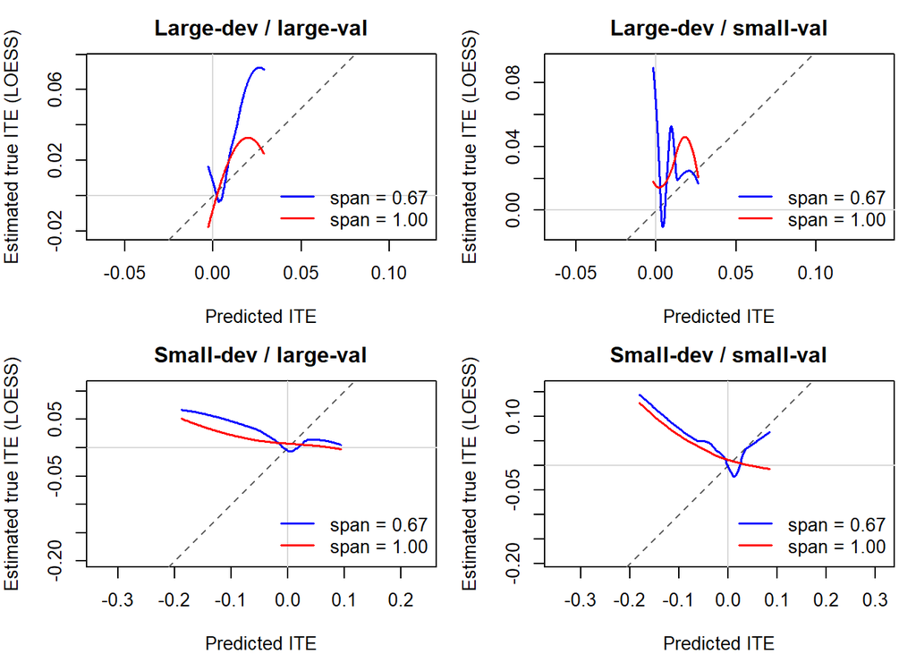

```r
# ... and draw again so it also appears inline when knitting
draw_flexcalib_grid()
```

### Bin-based calibration plots (experimental)

The grouping (quantile-binning) counterpart to the LOESS plots. Observations are split into equal-count bins of predicted ITE. Within each bin, the observed ITE is estimated as the difference in observed event rates between arms (control minus treated), and plotted against the mean predicted ITE in the bin. Each panel overlays two bin counts (4 and 5) on the same data to show how the analyst’s grouping choice shifts the qualitative read – the binning counterpart of the classic Hosmer-Lemeshow “number of groups” arbitrariness. Points are the per-bin observed ITEs with 95% confidence-interval whiskers; the dashed coloured lines connect the points within each bin count.

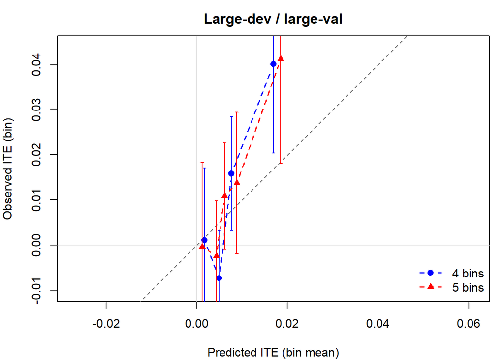

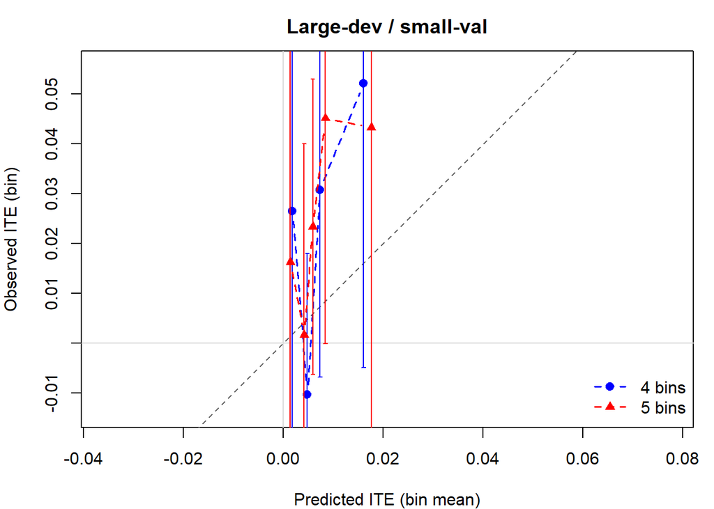

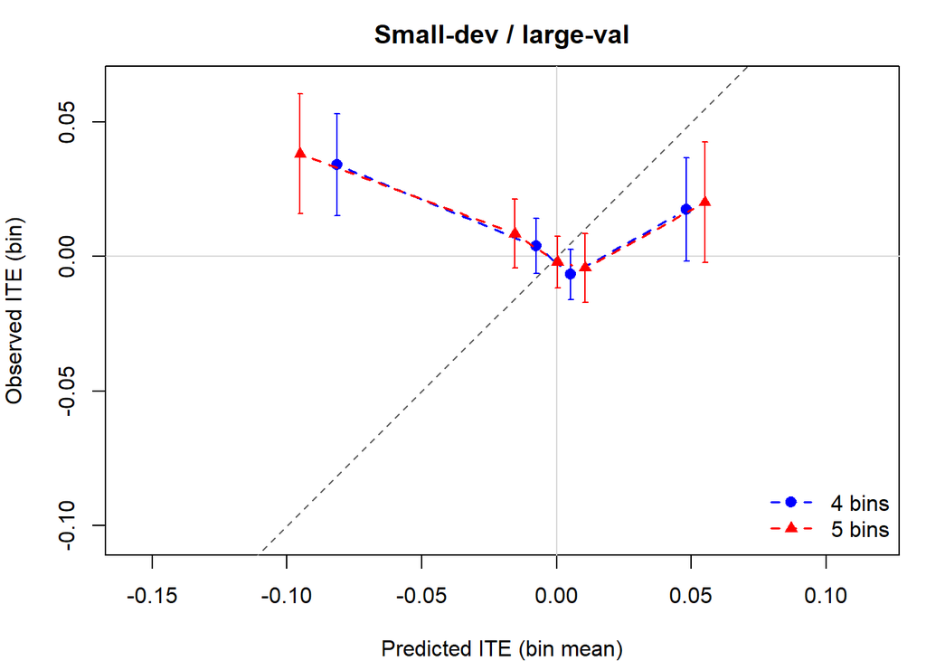

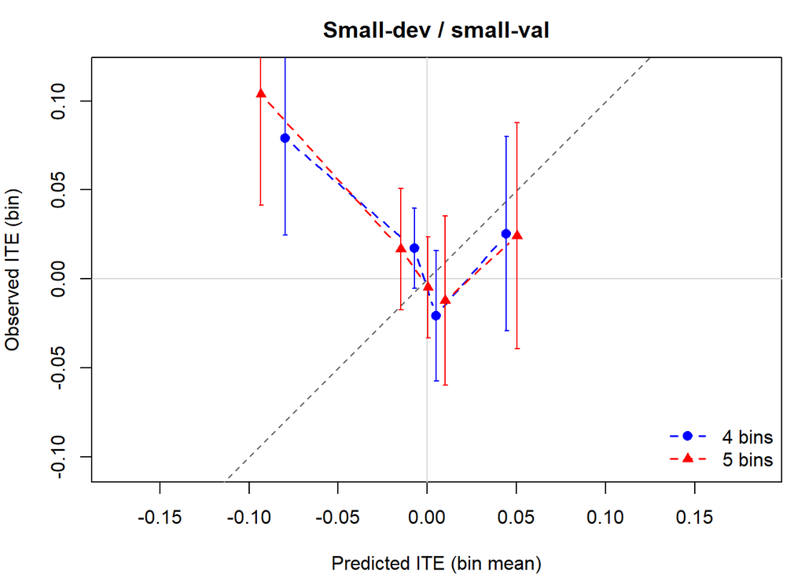

```r
bin_calib <- function(ite_model, val, nbins = 10) {
  tmp <- val; tmp$a <- 0; p0 <- predict(ite_model, newdata = tmp, type = "response")
  tmp$a <- 1;            p1 <- predict(ite_model, newdata = tmp, type = "response")
  d <- data.frame(Y = val$Y, h = p0 - p1, a = val$a)
  br <- quantile(d$h, probs = seq(0, 1, length.out = nbins + 1))
  d$bin <- cut(d$h, breaks = br, include.lowest = TRUE, labels = FALSE)
  out <- lapply(sort(unique(d$bin)), function(b) {
    db <- d[d$bin == b, ]
    y0 <- db$Y[db$a == 0]; y1 <- db$Y[db$a == 1]
    m0 <- mean(y0); m1 <- mean(y1)                          # arm event rates in bin
    data.frame(pred = mean(db$h), obs = m0 - m1,            # observed ITE in bin
               se = sqrt(m0 * (1 - m0) / length(y0) + m1 * (1 - m1) / length(y1)))
  })
  do.call(rbind, out)
}

draw_bincalib_overlay <- function(src, dest, nbins_set = c(4, 5),
                                  cols = c("blue", "red"), pchs = c(19, 17)) {
  par(mar = c(4, 4, 2.5, 1))
  bcs <- lapply(nbins_set, function(nb)
    bin_calib(get(paste0("ite_model", src)), get(paste0("val_data", dest)), nb))
  # Equal aspect with a common 45-degree range from the bin means and observed
  # ITEs at both bin counts. The CI whiskers still draw but clip in the tails.
  allx <- unlist(lapply(bcs, `[[`, "pred"))
  ally <- unlist(lapply(bcs, `[[`, "obs"))
  lim <- extendrange(c(allx, ally), f = 0.06)
  plot(NA, asp = 1, xlim = lim, ylim = lim,
       xlab = "Predicted ITE (bin mean)", ylab = "Observed ITE (bin)",
       main = sprintf("%s-dev / %s-val",
                      ifelse(src == "L", "Large", "Small"),
                      ifelse(dest == "L", "large", "small")))
  abline(h = 0, v = 0, col = "grey85")
  abline(0, 1, col = "grey40", lty = 2)                     # identity = perfect calibration
  for (i in seq_along(bcs)) {
    lo <- bcs[[i]]$obs - 1.96 * bcs[[i]]$se
    hi <- bcs[[i]]$obs + 1.96 * bcs[[i]]$se
    arrows(bcs[[i]]$pred, lo, bcs[[i]]$pred, hi,             # 95% CI whiskers
           length = 0.02, angle = 90, code = 3, col = cols[i])
    lines(bcs[[i]]$pred, bcs[[i]]$obs, type = "b",           # dashed connector + points
          pch = pchs[i], col = cols[i], lwd = 1.6, lty = 2)
  }
  legend("bottomright", bty = "n", lwd = 1.6, lty = 2, pch = pchs, col = cols,
         legend = sprintf("%d bins", nbins_set))
}

# Bin-count sensitivity on ONE panel: 4 vs 5 quantile bins overlaid on the same
# data, without confidence intervals. One stand-alone figure per dev/val
# combination, so each can be copied individually into the response letter
# (response to Reviewer 2, R3).
for (src in c("L", "S"))
  for (dest in c("L", "S")) {
    fn <- paste0(res_path, "gusto_bincalib_", src, dest, "_bins.png")
    png(fn, width = 1500, height = 1500, res = 300)
    draw_bincalib_overlay(src, dest)
    dev.off()
    # ... and draw again so each figure also appears inline when knitting
    draw_bincalib_overlay(src, dest)
  }
```